# Tutorial: Bayesian Linear Regression via Exact Direct Sampling in RStan

Sudipto Banerjee

2026-08-02

*Note:* To generate this HTML file, run the compilation script in the terminal from the `src/bayesianLinearRegressionExact/rstan/run` directory.

```bash
# Navigate to the directory and run compilation
cd src/bayesianLinearRegressionExact/rstan/run
Rscript -e "rmarkdown::render('lmExactStan.Rmd')"
```

## Introduction

In conjugate normal-linear regression models, exact posterior draws can be computed directly using **Composition Sampling**. Because marginal samples for the precision parameter $\tau$ are drawn directly from a Gamma distribution and multivariate conditional draws for $\beta \mid \tau$ are generated in parallel via C++ RNG primitives, **no MCMC adaptation or burn-in phase is required**.

This tutorial demonstrates exact direct composition sampling translated to **RStan** using C++ RNG utilities evaluated under `algorithm = "Fixed_param"`, validated against closed-form analytical conjugate sampling in `spBayes`.

### Composition Sampling Overview

Composition sampling provides a method to draw exact samples from a joint distribution by utilizing marginal and conditional sampling. For two random variables $X$ and $Y$ with a joint density function $f(X,Y)$, the density at $(x,y)$ can be written as $f_{X,Y}(x,y) = f_X(x)f_{Y|X}(y|x)$. Suppose we can draw samples from $f_X$ and $f_{Y|X}$ for any given $X = x$. To generate $N$ samples from this joint distribution, one first draws a sample $X_i^* = x_i \sim f_X$ from the marginal distribution of $X$ for $i = 1, \dots, N$. Then, for each drawn value $x_i$, a subsequent sample $Y_i^* \sim f_{Y|X}(\cdot \mid x_i)$ is drawn for $i = 1, \dots, N$.

We offer some heuristics on why the distribution of the simulated random variables is $(X_i^*, Y_i^*) \stackrel{ind}{\sim} f_{X,Y}(\cdot, \cdot)$. It is clear that $P(X_i^* \leq u) = \int_{-\infty}^{u} f_X(x)dx$ because $X_i^* \sim f_X(\cdot)$, i.e., $X_i^*$ has the same distribution as $X$. And $P(Y_i^* \leq v \mid X_i^* = x) = \int_{-\infty}^{v} f_{Y \mid X}(y \mid x)dy$ because $Y_i^* \mid (X_i^* = x) \sim f_{Y \mid X}(\cdot \mid x)$. Therefore,

$$P(X_i^* \leq u, Y_i^* \leq v) =
\int_{-\infty}^{u} f_X(x) \int_{-\infty}^{v} f_{Y \mid X}(y \mid x)dydx
= \int_{-\infty}^{u} \int_{-\infty}^{v} f_X(x)f_{Y \mid X}(y \mid x)dydx
= P(X \leq u, Y \leq v).$$

Hence, $(X_i, Y_i) \stackrel{d}{=} (X,Y)$. Since each draw is independent across $i$, the samples are independent.

We can apply this method to draw samples from a joint posterior distribution,

$$p(\theta_1, \theta_2 \mid y) =
p(\theta_1 \mid y) \times p(\theta_2 \mid \theta_1, y).$$

In conjugate models, it is often easy to draw samples from $p(\theta_1 \mid y)$ and from $p(\theta_2 \mid \theta_1, y)$. We first draw $N$ samples $\theta_{1(i)} \sim p(\theta_1 \mid y)$ and, for each drawn value $\theta_{1(i)}$, we draw $\theta_{2(i)} \sim p(\theta_2 \mid \theta_{1(i)}, y)$. For example, specifically in Bayesian linear regression, we first draw $\sigma^2i_{(i)} \sim p(\sigma^2 \mid y)$ and then draw $\beta_{(i)} \sim p(\beta \mid y, \sigma^2_{(i)})$ using the previously drawn value of $\sigma^2_{(i)}$.

## 1. Helper Functions & Environment Setup

```r
library(spBayes)
library(rstan)
library(knitr)

# Source translated RStan composition sampler function
source("../src/compositionSamplingStan.r")
```

```r
# Load Data from two levels above rstan/run
rawData <- read.table("../../data/data.txt", header = TRUE)

# Prepare response and scaled design matrix
Y <- rawData$Y
X_raw <- as.matrix(rawData[, -1])
X_scaled <- scale(X_raw)
X <- cbind(Intercept = 1, X_scaled)

N <- nrow(X)
P <- ncol(X)
n_samples <- 5000

# Shared Prior Specifications (Prior Precision Factor M0_inv)
M0_inv <- diag(0.01, P)
m0     <- rep(0, P)
a0     <- 0.01
b0     <- 0.01

cat("Dataset loaded successfully:", N, "observations and", P, "predictors.\n")
```

```
## Dataset loaded successfully: 1369 observations and 9 predictors.
```

## 2. Direct Composition Sampler in RStan

Using `run_direct_stan_composition()`, RStan receives the analytical posterior parameter values ($m_n$, $\Lambda_n^{-1}$, $a_n$, $b_n$) and uses its compiled C++ RNG routines to draw $M_{\text{samples}}$ independent joint posterior draws without standard Markov chain iterations.

```r
set.seed(123)

cat("Compiling and executing exact direct sampling in RStan...\n")
```

```
## Compiling and executing exact direct sampling in RStan...
```

```r
runtime_stan <- system.time({
  stan_dir_results <- run_direct_stan_composition(
    X = X, Y = Y, n_samples = n_samples,
    a0 = a0, b0 = b0, m0 = m0, M0_inv = M0_inv
  )
})
```

```
## Compiling and executing Stan C++ Direct Sampler...
```

```r
print(runtime_stan)
```

```
##    user  system elapsed
##  79.392   3.782  82.754
```

```r
stan_samples <- stan_dir_results$draws

summary_stan <- round(cbind(Mean = colMeans(stan_samples), SD = apply(stan_samples, 2, sd)), 4)
kable(summary_stan, caption = "RStan Direct Composition Posterior Summary")
```

RStan Direct Composition Posterior Summary

|  | Mean | SD |
| --- | --- | --- |
| beta[1] | 11.6840 | 0.0042 |
| beta[2] | 0.2963 | 0.0059 |
| beta[3] | -0.0386 | 0.0061 |
| beta[4] | -0.0347 | 0.0060 |
| beta[5] | -0.0328 | 0.0042 |
| beta[6] | 0.0129 | 0.0042 |
| beta[7] | 0.1116 | 0.0217 |
| beta[8] | -0.0650 | 0.0084 |
| beta[9] | -0.1457 | 0.0222 |
| sigma2 | 0.0238 | 0.0009 |
| tau | 42.0868 | 1.5894 |
| sigma | 0.1542 | 0.0029 |

## 3. RStan Direct vs. `spBayes::bayesLMConjugate` Q-Q Plots

To verify statistical equivalence, we construct quantile-quantile (Q-Q) plots comparing the empirical distributions generated by RStan against the closed-form benchmark in `spBayes`.

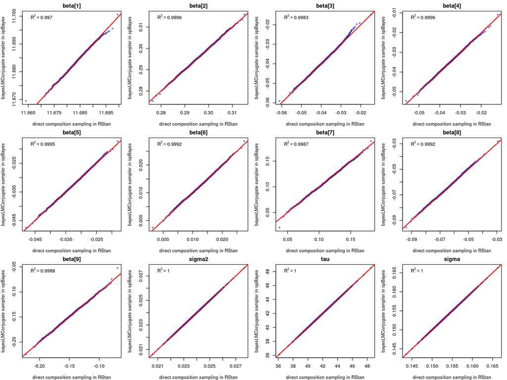

```r
df <- data.frame(Y = Y, X_scaled)

set.seed(123)
spb_model <- bayesLMConjugate(
  formula = Y ~ ., data = df, n.samples = n_samples,
  beta.prior.mean = m0, beta.prior.precision = M0_inv,
  prior.shape = a0, prior.rate = b0
)

spb_raw     <- spb_model$p.beta.tauSq.samples
spb_samples <- cbind(spb_raw[, 1:P], sigma2 = spb_raw[, P + 1], tau = 1/spb_raw[, P + 1], sigma = sqrt(spb_raw[, P + 1]))
colnames(spb_samples) <- colnames(stan_samples)

par(mfrow = c(3, 4), mar = c(4, 4, 2, 1))
param_names <- colnames(stan_samples)

stan_mat <- as.matrix(stan_samples)
spb_mat  <- as.matrix(spb_samples)

for (param in param_names) {
  x_stan_raw <- as.numeric(stan_mat[, param])
  y_spb_raw  <- as.numeric(spb_mat[, param])

  # Quantile calculation for consistent plot resolution and alignment
  q_stan <- quantile(x_stan_raw, probs = seq(0, 1, length.out = 1000), na.rm = TRUE)
  q_spb  <- quantile(y_spb_raw, probs = seq(0, 1, length.out = 1000), na.rm = TRUE)

  r2 <- cor(q_stan, q_spb)^2

  plot(q_stan, q_spb,
       main = param,
       xlab = "direct composition sampling in RStan",
       ylab = "bayesLMConjugate sampler in spBayes",
       pch = 20, col = rgb(0.1, 0.2, 0.7, alpha = 0.5))

  abline(a = 0, b = 1, col = "red", lwd = 2)
  legend("topleft", legend = bquote(R^2 == .(format(r2, digits = 4))),
         bty = "n", text.col = "black")
}
```

```r
par(mfrow = c(1, 1))
```